# How do teams do after a good game?

#### Read in the data

```r
game_data = read_csv("./logs/gl2022.csv", col_names = FALSE)
game_log_header = read_csv("https://raw.githubusercontent.com/maxtoki/baseball_R/master/data/game_log_header.csv", col_names = FALSE)
colnames(game_data) = game_log_header
game_data = game_data %>% rename(HomeRunsScored = HomeRunsScore) # fix error in name
```

```r
# Fix some errors in the data
game_data = game_data %>%
  mutate(HomeTeamLeague = replace(HomeTeamLeague, HomeTeamLeague == 'NL.1', 'NL'))
```

```r
# Make the date format more readable
game_data[["Date"]] = as.Date(as.character(game_data[["Date"]]), "%Y%m%d")
```

```r
# Create an ID number for each game in order to reference back to games.
ids = seq(1:as.integer(count(game_data)))

game_data = game_data %>%
  mutate(ID = ids) %>%
  relocate(ID, .after = Date)
```

#### The Question

Every once in a while, an MLB game will end with a team scoring an abnormal amount of runs. Question one asks: In **2022**:

> **How does the next game go after scoring a lot of runs?**

#### Choose which columns to keep

Ideally to answer this question, we will want to keep the date, teams, runs scored, and maybe a few other smaller factors.

```r
games_q1 = game_data %>%
  select(Date, VisitingTeam, VisitingTeamLeague, HomeTeam, HomeTeamLeague, VisitorRunsScored, HomeRunsScored, ID)
head(games_q1) %>%
  kbl() %>%
  kable_styling(c("striped", "hover"))
```

| Date | VisitingTeam | VisitingTeamLeague | HomeTeam | HomeTeamLeague | VisitorRunsScored | HomeRunsScored | ID |
| --- | --- | --- | --- | --- | --- | --- | --- |
| 2022-04-07 | SDN | NL | ARI | NL | 2 | 4 | 1 |
| 2022-04-07 | CIN | NL | ATL | NL | 6 | 3 | 2 |
| 2022-04-07 | MIL | NL | CHN | NL | 4 | 5 | 3 |
| 2022-04-07 | PIT | NL | SLN | NL | 0 | 9 | 4 |
| 2022-04-07 | NYN | NL | WAS | NL | 5 | 1 | 5 |
| 2022-04-07 | HOU | AL | ANA | AL | 3 | 1 | 6 |

#### Get each team’s average runs scored per game

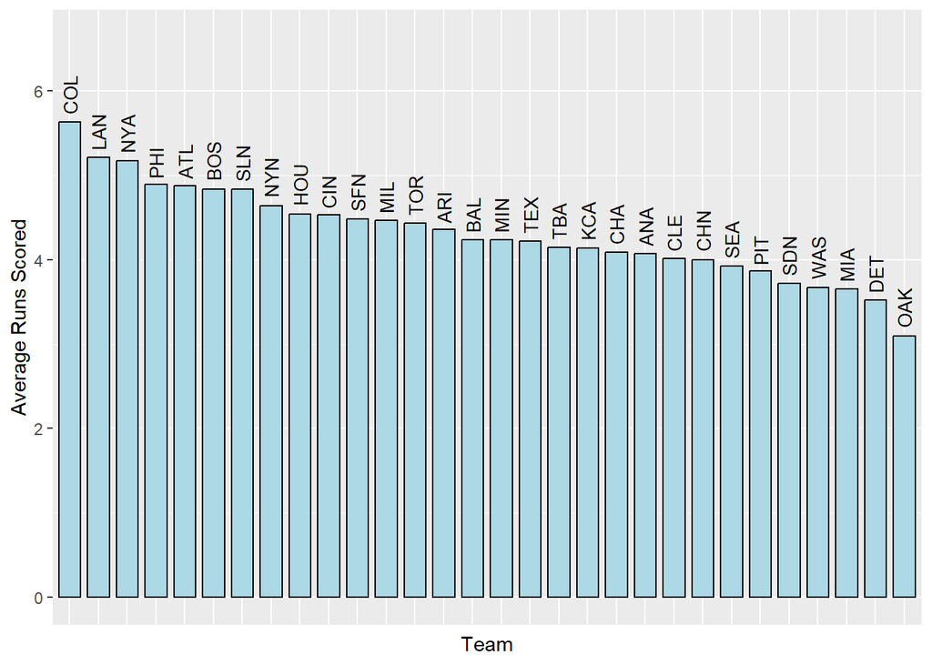

```r
runs_scored_as_home = game_data %>%
  group_by(HomeTeam) %>%
  summarize(runs_scored = sum(HomeRunsScored)) %>%
  rename(Team = HomeTeam)

runs_scored_as_vis = game_data %>%
  group_by(VisitingTeam) %>%
  summarize(runs_scored = sum(VisitorRunsScored)) %>%
  rename(Team = VisitingTeam)

total_scored = merge(runs_scored_as_home, runs_scored_as_home, by = "Team") %>%
  mutate(total_runs_scored = runs_scored.x + runs_scored.y) %>%
  select(Team, total_runs_scored)

avg_scored_per_game = total_scored %>%
  mutate(avg_runs_scored = total_runs_scored/162) %>%
  select(Team, avg_runs_scored) %>%
  arrange(desc(avg_runs_scored))

max_runs_scored = max(avg_scored_per_game$avg_runs_scored)

ggplot(avg_scored_per_game, aes(reorder(Team, -avg_runs_scored), avg_runs_scored)) +
  geom_col(fill = "lightblue", color="black", width = 0.75) +
  geom_text(aes(label = Team), hjust = -0.2, color= "black", angle = 90, size = 3.5) +
  ylim(0, max_runs_scored + 1) +
  theme(axis.text.x = element_blank(), axis.ticks.x = element_blank()) +
  xlab("Team") +
  ylab("Average Runs Scored")
```

#### Find each teams runs scored after scoring a lot of runs.

What is a lot of runs? To define this we’ll take a look at all of the instances of runs scored.

```r
instances = c(games_q1$VisitorRunsScored, games_q1$HomeRunsScored)
high_quantile = as.double(quantile(instances, c(0.95)))
high_quantile
```

```
## [1] 10
```

So we’ll look at when teams score in the 95th percentile and above, or more than 10 runs.

```r
visitors_more_than_8_runs = games_q1 %>%
  filter(VisitorRunsScored > high_quantile) %>%
  select(Date, VisitingTeam, VisitingTeamLeague, VisitorRunsScored, ID)

home_more_than_8_runs = games_q1 %>%
  filter(HomeRunsScored > high_quantile) %>%
  select(Date, HomeTeam, HomeTeamLeague, HomeRunsScored, ID)
```

Create a function that finds a team’s next game after the game specified, and returns the number of runs they scored.

```r
runs_scored_next_game = function(game_id, team) {

  if (game_id < 1 | game_id > as.integer(count(games_q1))){
    stop("Invalid ID Number.")
  }
  if (!(team %in% games_q1$HomeTeam) || !(team %in% games_q1$VisitingTeam)) {
    stop("Team not found.")
  }

  current_game = games_q1 %>%
    filter(ID == game_id)

   if (!(team %in% current_game$HomeTeam) && !(team %in% current_game$VisitingTeam)) {
     stop("This team did not play in this game.")
   }

  # The next game is the next row in the table after 24 that has the team as one of the two teams listed.
  next_games = games_q1 %>%
    filter(ID > game_id & (HomeTeam == team | VisitingTeam == team))
  next_game = c(head(next_games, 1))

  if (length(next_game$HomeTeam) == 0){
    return(NA)
  }

  runs_scored_in_game = NULL

  if (team == next_game$HomeTeam) {
    runs_scored_in_game = next_game$HomeRunsScored
  } else if (team == next_game$VisitingTeam) {
    runs_scored_in_game = next_game$VisitorRunsScored
  }
  return (runs_scored_in_game)
}
```

Now, let’s combine both home and away into one data frame, and add the number of runs they scored in their next game.

```r
# Rename columns in both dataframes, and add column for home or visitor
home_more_than_8_runs = home_more_than_8_runs %>%
  rename(Team = HomeTeam, League = HomeTeamLeague, RunsScored = HomeRunsScored) %>%
  mutate("H/V" = "H")

visitors_more_than_8_runs = visitors_more_than_8_runs %>%
  rename(Team = VisitingTeam, League = VisitingTeamLeague, RunsScored = VisitorRunsScored) %>%
  mutate("H/V" = "V")
```

```r
# Combine data into one dataframe
more_than_8_runs = rbind(home_more_than_8_runs, visitors_more_than_8_runs) %>% arrange(Date)
```

Now, let’s add the number of runs they scored the game after.

```r
# mutate a new column, and call the function we made
vectorized_func = Vectorize(runs_scored_next_game)
runs_inc_next_game = more_than_8_runs %>%
  mutate(RunsNextGame = vectorized_func(ID, Team))
```

```r
# NOTE! If the runs scored next game column contains an NA, that means that was the last game of the season for that team.
# Here are the first few rows
head(runs_inc_next_game) %>%
  kbl() %>%
  kable_styling(c("striped", "hover"))
```

| Date | Team | League | RunsScored | ID | H/V | RunsNextGame |
| --- | --- | --- | --- | --- | --- | --- |
| 2022-04-08 | HOU | AL | 13 | 14 | V | 0 |
| 2022-04-10 | CLE | AL | 17 | 45 | V | 10 |
| 2022-04-10 | TEX | AL | 12 | 49 | V | 4 |
| 2022-04-11 | WAS | NL | 11 | 50 | V | 4 |
| 2022-04-11 | OAK | AL | 13 | 59 | V | 8 |
| 2022-04-12 | ATL | NL | 16 | 62 | H | 1 |

Now let’s find the MLB Average of runs scored after, as well as the individual leagues and teams.

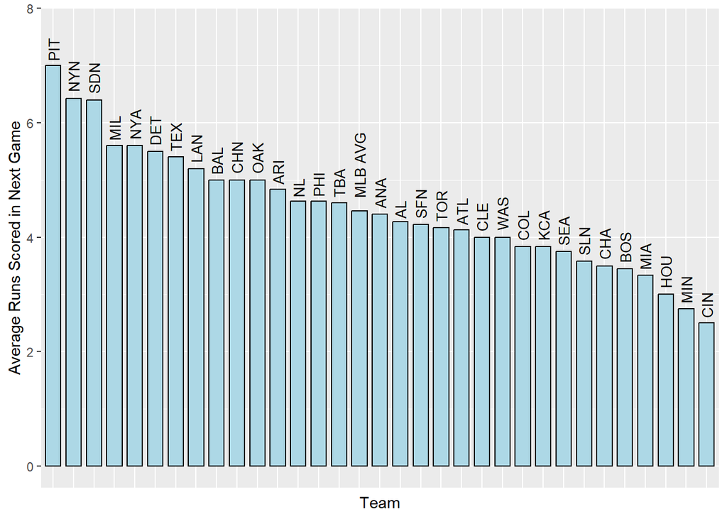

```r
by_team = runs_inc_next_game %>%
  drop_na() %>%
  group_by(Team) %>%
  summarize(AvgNextGame = round(mean(RunsNextGame), 3)) %>%
  rename(Group = Team) %>%
  arrange(desc(AvgNextGame))

mlb = runs_inc_next_game %>%
  drop_na() %>%
  summarize(AvgNextGame = round(mean(RunsNextGame), 3)) %>%
  mutate(Group = "MLB AVG") %>%
  relocate(Group, .before = AvgNextGame)

by_league = runs_inc_next_game %>%
  drop_na() %>%
  group_by(League) %>%
  summarize(AvgNextGame = round(mean(RunsNextGame), 3)) %>%
  rename(Group = League) %>%
  arrange(desc(AvgNextGame))

Avg_NextGame_All = rbind(mlb, by_league, by_team)



# Final Output
ggplot(Avg_NextGame_All, aes(x = reorder(Group, -AvgNextGame), y =AvgNextGame)) + geom_col(fill = "lightblue", color="black", width = 0.75) +
  geom_text(aes(label = Group), hjust = -0.2, color= "black", angle = 90, size = 3.5) +
  ylim(0, max_runs_scored + 2) +
  theme(axis.text.x = element_blank(), axis.ticks.x = element_blank()) +
  xlab("Team") +
  ylab("Average Runs Scored in Next Game")
```

#### Rank Differences

Now let’s find some differences in ranks between runs scored after big game, and runs scored in general. Essentially, did the best run scoring teams do well off of big games?

```r
# Get teams, add ranks for avg next game
avg_next_game_ranks = Avg_NextGame_All %>%
  filter(!(Group %in% c("MLB AVG", "NL", "AL"))) %>%
  rename(Team = Group) %>%
  mutate(Rank = 1:length(Team))

# Get teams, add rank for total run scoring
avg_scored_per_game_ranks = avg_scored_per_game %>%
  mutate(Rank = 1:length(Team))

rank_diffs = avg_next_game_ranks %>% inner_join(avg_scored_per_game_ranks, by = "Team") %>% mutate(RankDiff = Rank.y - Rank.x) %>% select(Team, RankDiff) %>% arrange(desc(RankDiff))
rank_diffs %>%
  mutate(RankDiff = cell_spec(RankDiff, color = ifelse(RankDiff > 0, "green", "red"))) %>%
  kbl(escape = FALSE) %>%
  kable_styling(c("striped", "hover"))
```

| Team | RankDiff |
| --- | --- |
| PIT | 24 |
| SDN | 23 |
| DET | 23 |
| OAK | 19 |
| CHN | 13 |
| TEX | 10 |
| MIL | 8 |
| WAS | 7 |
| NYN | 6 |
| BAL | 6 |
| ANA | 6 |
| TBA | 4 |
| CLE | 3 |
| ARI | 2 |
| SEA | 1 |
| MIA | 1 |
| NYA | -2 |
| KCA | -3 |
| TOR | -4 |
| SFN | -5 |
| CHA | -5 |
| LAN | -6 |
| PHI | -9 |
| ATL | -13 |
| MIN | -13 |
| SLN | -17 |
| HOU | -19 |
| COL | -20 |
| BOS | -20 |
| CIN | -20 |

Plot Runs Scored vs Runs Scored after Big Game

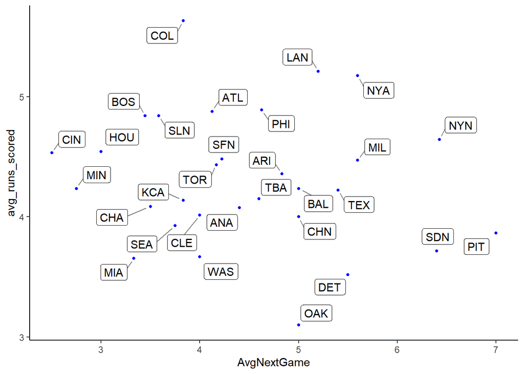

```r
runs_combined = avg_next_game_ranks %>% inner_join(avg_scored_per_game_ranks, by = "Team") %>% select(Team, avg_runs_scored, AvgNextGame)

ggplot(runs_combined, aes(x = AvgNextGame, y = avg_runs_scored)) +
  geom_point(color = "blue", size = 1) +
  geom_label_repel(aes(label = Team), box.padding = 0.35, point.padding = 0.5, segment.color = 'grey50') + theme_classic()
```